# Gene set analysis workflow with gVenn: identifying overlaps and shared genes

- Show All Code
- Hide All Code
- View Source

Supplementary data S2

Last updated

29 September 2026

**NoteInteractive notebook**

This analysis workflow is available online at:  
**https://ckntav.github.io/gVenn_manuscript/supp_data_S2.html**

[figure not shown]

# 1 Overview

This supplementary material demonstrates a complete gene set analysis workflow using the **gVenn** R package. The workflow includes computing overlaps between gene lists, visualizing results with Venn diagrams and UpSet plots, extracting overlap groups, and exporting results for downstream analysis.

# 2 Installation

The gVenn package is available through Bioconductor and GitHub.

You can install it from Bioconductor using:

```r
# From Bioconductor
if (!require("BiocManager", quietly = TRUE))
    install.packages("BiocManager")
BiocManager::install("gVenn")
```

The Bioconductor release version may lag behind development, so the newest features are not always available there. To install the development version from GitHub, use:

```r
# install.packages("pak")  # if not already installed
pak::pak("ckntav/gVenn")

# or, alternatively:
# install.packages("devtools")  # if not already installed
devtools::install_github("ckntav/gVenn")
```

# 3 Load required packages

```r
library(gVenn)
library(knitr)
```

## 3.1 Checking gVenn version

```r
packageVersion("gVenn")
```

```
[1] '1.99.0'
```

This workflow requires gVenn version 1.99.0 or later. Earlier versions do not provide all the functions used below.

# 4 Example dataset

The **gVenn** package includes a synthetic gene list dataset (`gene_list`) comprising three sets of human gene symbols with designed overlaps. This dataset was generated from the first 250 gene symbols in the `org.Hs.eg.db` package using a reproducible random seed.

```r
# Load the example gene list dataset
data(gene_list)

# Display the structure of the dataset
str(gene_list)
```

```
List of 3
 $ random_genes_A: chr [1:125] "ALPP" "ACTG1P9" "AHSG" "ASIC2" ...
 $ random_genes_B: chr [1:115] "AFM" "ADPRH" "AIF1" "ACVR2A" ...
 $ random_genes_C: chr [1:70] "ACTN1" "ALDOA" "CRYBG1" "AK4" ...
```

The dataset contains three gene lists with the following sizes:

```r
# Create a summary table
summary_df <- data.frame(
  "gene list" = names(gene_list),
  "number of genes" = sapply(gene_list, length),
  check.names = FALSE
)

kable(summary_df,
      caption = "Summary of example gene lists")
```

Summary of example gene lists

|  | gene list | number of genes |
| --- | --- | --- |
| random_genes_A | random_genes_A | 125 |
| random_genes_B | random_genes_B | 115 |
| random_genes_C | random_genes_C | 70 |

# 5 Computing overlaps

The `computeOverlaps()` function analyzes the intersection patterns across all gene lists and returns a structured object containing:

- A vector of all unique elements across sets
- A logical matrix indicating set membership for each element
- Category labels encoding the overlap pattern (e.g., “110”, “101”)

```r
# Compute overlaps between gene lists
gene_overlaps <- computeOverlaps(gene_list)

# Display the structure of the result
class(gene_overlaps)
```

```
[1] "SetOverlapResult"
```

```r
names(gene_overlaps)
```

```
[1] "unique_elements"    "overlap_matrix"     "intersect_category"
```

## 5.1 Overlap matrix

The overlap matrix shows which genes belong to which sets:

```r
# Display the first 10 rows of the overlap matrix
kable(head(gene_overlaps$overlap_matrix, 10),
      caption = "First 10 rows of the overlap matrix (TRUE = gene present in set)")
```

First 10 rows of the overlap matrix (TRUE = gene present in set)

|  | random_genes_A | random_genes_B | random_genes_C |
| --- | --- | --- | --- |
| ALPP | TRUE | FALSE | FALSE |
| ACTG1P9 | TRUE | FALSE | FALSE |
| AHSG | TRUE | FALSE | FALSE |
| ASIC2 | TRUE | FALSE | FALSE |
| ACTG1P10 | TRUE | FALSE | FALSE |
| ALAS1 | TRUE | FALSE | FALSE |
| AKT2 | TRUE | FALSE | FALSE |
| PARP1P1 | TRUE | FALSE | FALSE |
| ABCD1 | TRUE | FALSE | FALSE |
| SLC25A6 | TRUE | FALSE | FALSE |

## 5.2 Overlap categories

Each gene is assigned a category code representing its overlap pattern. The number of genes per pattern is given in Extracting overlap groups.

- `100`: Genes only in set A (random_genes_A)
- `010`: Genes only in set B (random_genes_B)
- `001`: Genes only in set C (random_genes_C)
- `110`: Genes in A ∩ B (not in C)
- `101`: Genes in A ∩ C (not in B)
- `011`: Genes in B ∩ C (not in A)
- `111`: Genes in A ∩ B ∩ C (all three sets)

# 6 Visualization

## 6.1 Venn diagram

The `plotVenn()` function creates area-proportional Venn diagrams to visualize the overlaps:

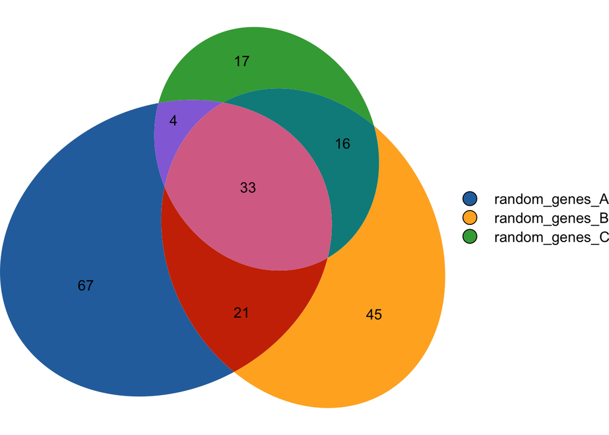

Figure 1: Basic Venn diagram showing overlaps between three gene lists

```r
# Create a basic Venn diagram
plotVenn(gene_overlaps)
```

### 6.1.1 Customized Venn diagram

The appearance can be customized by adjusting colors, transparency, labels, and other parameters:

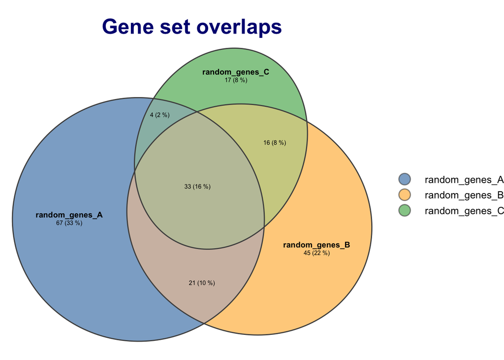

Figure 2: Customized Venn diagram with adjusted colors and transparency

```r
# Create a customized Venn diagram
plotVenn(gene_overlaps,
         fills = list(fill = c("#2B70AB", "#FFB027", "#3EA742"), alpha = 0.6),
         edges = list(col = "gray30", lwd = 1.5),
         labels = list(col = "black", fontsize = 8, font = 2),
         quantities = list(type = c("counts", "percent"),
                          col = "black", fontsize = 6),
         main = list(label = "Gene set overlaps",
                    fontsize = 14, font = 2, col = "navy"),
         legend = list(side = "right", fontsize = 10))
```

## 6.2 UpSet plot

For larger numbers of sets (>3), UpSet plots provide a clearer alternative to Venn diagrams:

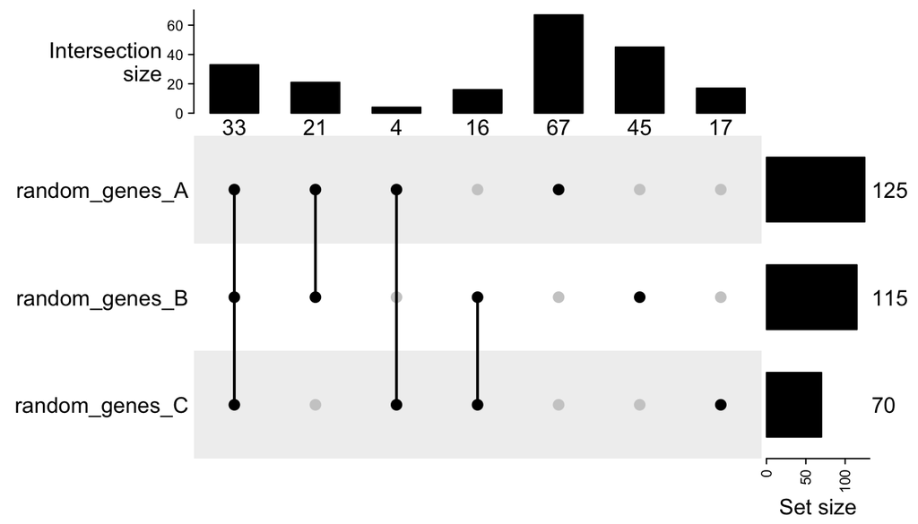

Figure 3: UpSet plot showing intersection sizes between gene lists

```r
# Create an UpSet plot
plotUpSet(gene_overlaps)
```

### 6.2.1 Customized UpSet plot

The UpSet plot can also be customized with colors:

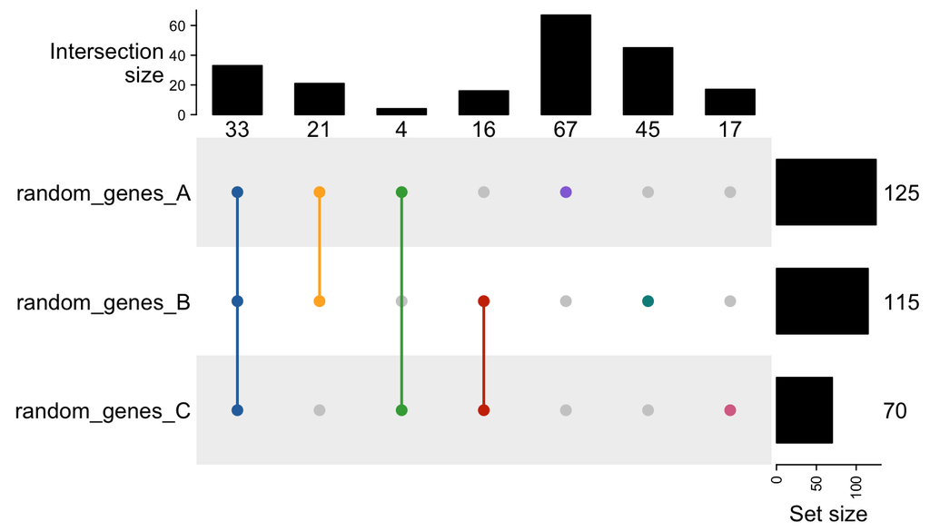

Figure 4: Customized UpSet plot with colored combination matrix

```r
# Create a customized UpSet plot with colored dots
plotUpSet(gene_overlaps,
          comb_col = c("#2B70AB", "#FFB027", "#3EA742", "#CD3301",
                      "#9370DB", "#008B8B", "#D87093"))
```

# 7 Extracting overlap groups

The `extractOverlaps()` function separates genes into distinct groups based on their overlap patterns:

```r
# Extract genes grouped by overlap pattern
gene_groups <- extractOverlaps(gene_overlaps)

# Display the number of genes per group
group_sizes <- sapply(gene_groups, length)
group_df <- data.frame(
  "Overlap group" = names(group_sizes),
  "Number of genes" = as.integer(group_sizes),
  check.names = FALSE
)

kable(group_df,
      caption = "Number of genes in each overlap group")
```

Number of genes in each overlap group

| Overlap group | Number of genes |
| --- | --- |
| group_001 | 17 |
| group_010 | 45 |
| group_100 | 67 |
| group_011 | 16 |
| group_101 | 4 |
| group_110 | 21 |
| group_111 | 33 |

## 7.1 Examining specific groups

Individual overlap groups can be accessed for downstream analysis:

### 7.1.1 Extract genes present in all three sets (group_111)

```r
# Extract genes present in all three sets (group_111)
genes_in_all_three <- gene_groups[["group_111"]]

cat("Genes present in all three sets (A ∩ B ∩ C):\n")
```

```
Genes present in all three sets (A ∩ B ∩ C):
```

```r
print(genes_in_all_three)
```

```
 [1] "ACP2"      "ALDH3A1"   "ACTB"      "ACACA"     "ASIC1"     "SLC25A5"
 [7] "ACTL6A"    "AMY2B"     "AMH"       "AMPH"      "ADK"       "ALDH3A2"
[13] "ACTG1P3"   "ACO1"      "ACTG1P7"   "ALPI"      "ANXA4"     "AGL"
[19] "ADRB2"     "ABCF1"     "ABO"       "AMD1"      "ALS3"      "ALOX12"
[25] "AMBP"      "AMPD2"     "ALDH1A1"   "AFG3L1P"   "ADFN"      "ADCYAP1R1"
[31] "ADD3"      "ALOX12P2"  "BIN1"
```

### 7.1.2 Extract genes unique to random_genes_A (group_100)

```r
# Extract genes unique to random_genes_A (group_100)
genes_unique_to_A <- gene_groups[["group_100"]]

cat("Genes unique to random_genes_A:\n")
```

```
Genes unique to random_genes_A:
```

```r
print(genes_unique_to_A)
```

```
 [1] "ALPP"     "ACTG1P9"  "AHSG"     "ASIC2"    "ACTG1P10" "ALAS1"
 [7] "AKT2"     "PARP1P1"  "ABCD1"    "SLC25A6"  "AAMP"     "ADCP1"
[13] "ACADVL"   "ACTG1"    "ANGPT2"   "AGTR1"    "ACACB"    "ACTBP9"
[19] "ALDH1B1"  "ADAR"     "ABCD2"    "AMHR2"    "ABCB7"    "ABCA1"
[25] "PARP4"    "ACTG1P1"  "JAG1"     "ACTA2"    "ADH7"     "AP1B1"
[31] "ACVR1"    "ACTN4"    "A2MP1"    "ABCA4"    "ALAD"     "ADRA1A"
[37] "ADCY5"    "ALDOB"    "AP2B1"    "AMELY"    "ABL1"     "ACTC1"
[43] "AK2"      "ALOX12B"  "ACTN3"    "AIC"      "ALB"      "NATP"
[49] "ANG"      "AHR"      "ABCA2"    "ALPL"     "ANXA2P1"  "AMELX"
[55] "AHCY"     "PARP1P2"  "ALOX5"    "AMPD1"    "AFA"      "ACADSB"
[61] "AIH3"     "ACAN"     "AGA"      "AMY1C"    "ADSS2"    "ALDH2"
[67] "ALOX15B"
```

# 8 Exporting results

## 8.1 Export to Excel

The `exportOverlaps()` function exports each overlap group to a separate sheet in an Excel file:

```r
# Export overlap groups to Excel
exportOverlaps(gene_groups,
               output_dir = "results",
               output_file = "gene_overlap_groups",
               with_date = TRUE,
               verbose = TRUE)
```

This creates an Excel file with one sheet per overlap group, making it easy to:

- Review genes in each category
- Perform functional enrichment analysis
- Share results with collaborators
- Import into other analysis tools

## 8.2 Saving visualizations

Visualizations can be exported in multiple formats (PDF, PNG, SVG):

```r
# Create a Venn diagram
venn_plot <- plotVenn(gene_overlaps)

# Save as PDF
saveViz(venn_plot,
        output_dir = "figures",
        output_file = "gene_venn_diagram",
        format = "pdf",
        width = 6,
        height = 4)

# Save as high-resolution PNG
saveViz(venn_plot,
        output_dir = "figures",
        output_file = "gene_venn_diagram",
        format = "png",
        width = 6,
        height = 4,
        resolution = 300)

# Save with transparent background for presentations
saveViz(venn_plot,
        output_dir = "figures",
        output_file = "gene_venn_diagram_transparent",
        format = "png",
        bg = "transparent")
```

# 9 References

For more information about the gVenn package, visit:

- Package documentation: https://ckntav.github.io/gVenn
- GitHub repository: https://github.com/ckntav/gVenn

© 2026 [Christophe Tav](https://ckntav.github.io/)